## 0.1 [The *pls* Package: Principal Component and Partial Least Squares Regression in R](https://www.jstatsoft.org/article/view/v018i02)

Z abstraktu artykułu: “Pakiet pls implementuje regresję głównych składników (PCR) i częściową regresję najmniejszych kwadratów (PLSR) w R. (…) Kontrola wizualna i ocena jest ważna w chemometrii, a pakiet pls posiada szereg funkcji wykresów punktacji, obciążeń, przewidywań, współczynników i szacunków RMSEP.”

Poniżej znajdują się wyniki przykładowego kodu z artykułu.

```r
###################################################
library("pls")
###################################################
data("yarn")
data("oliveoil")
data("gasoline")
```

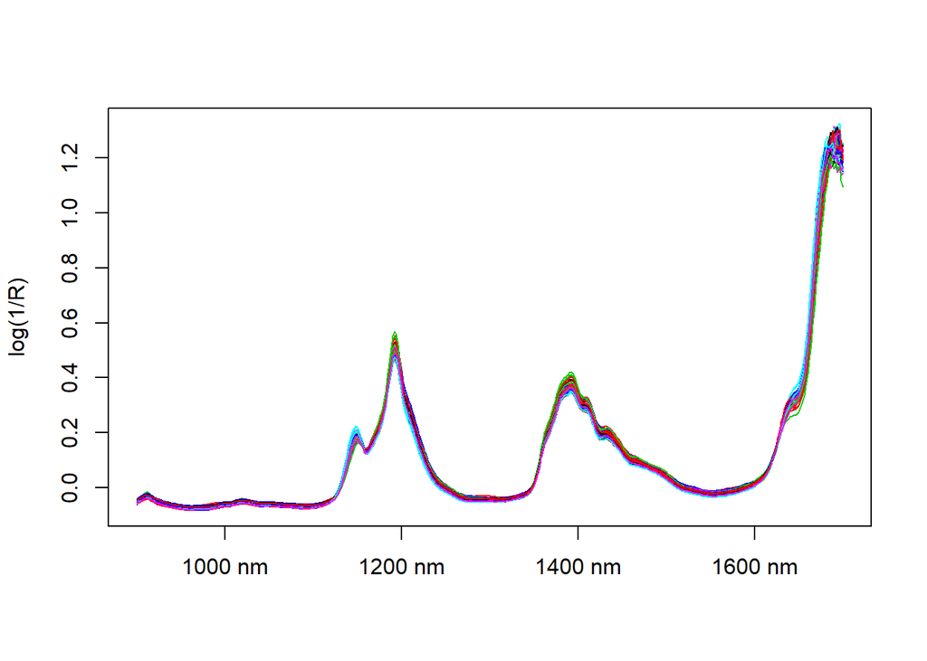

```r
###################################################
matplot(t(gasoline$NIR), type = "l", lty = 1, ylab = "log(1/R)", xaxt = "n")
ind <- pretty(seq(from = 900, to = 1700, by = 2))
ind <- ind[ind >= 900 & ind <= 1700]
ind <- (ind - 898) / 2
axis(1, ind, colnames(gasoline$NIR)[ind])
```

```r
###################################################
gasTrain <- gasoline[1:50,]
gasTest <- gasoline[51:60,]
```

```r
###################################################
gas1 <- plsr(octane ~ NIR, ncomp = 10, data = gasTrain, validation = "LOO")
```

```r
###################################################
summary(gas1)
```

```
## Data:    X dimension: 50 401
##  Y dimension: 50 1
## Fit method: kernelpls
## Number of components considered: 10
##
## VALIDATION: RMSEP
## Cross-validated using 50 leave-one-out segments.
##        (Intercept)  1 comps  2 comps  3 comps  4 comps  5 comps  6 comps
## CV           1.545    1.357   0.2966   0.2524   0.2476   0.2398   0.2319
## adjCV        1.545    1.356   0.2947   0.2521   0.2478   0.2388   0.2313
##        7 comps  8 comps  9 comps  10 comps
## CV      0.2386   0.2316   0.2449    0.2673
## adjCV   0.2377   0.2308   0.2438    0.2657
##
## TRAINING: % variance explained
##         1 comps  2 comps  3 comps  4 comps  5 comps  6 comps  7 comps  8 comps
## X         78.17    85.58    93.41    96.06    96.94    97.89    98.38    98.85
## octane    29.39    96.85    97.89    98.26    98.86    98.96    99.09    99.16
##         9 comps  10 comps
## X         99.02     99.19
## octane    99.28     99.39
```

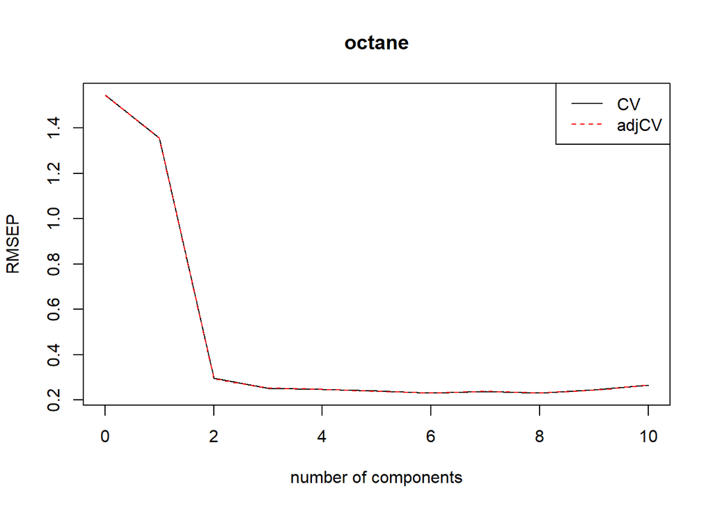

```r
###################################################
plot(RMSEP(gas1), legendpos = "topright")
```

Zarówno wykres powyżej jak i 2 dalsze wykresy wydają się za to identyczne.

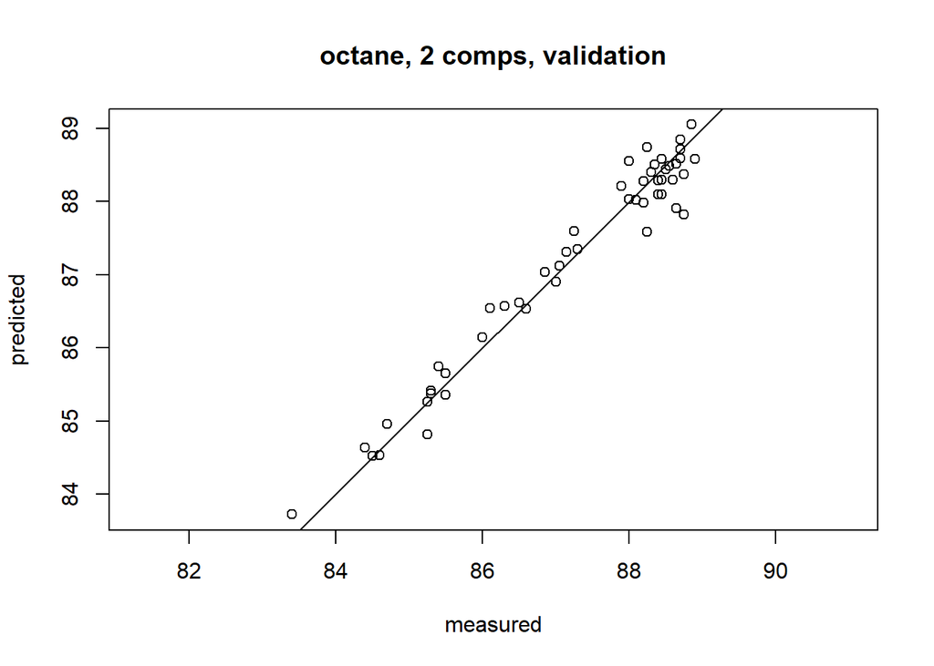

```r
###################################################
plot(gas1, ncomp = 2, asp = 1, line = TRUE)
```

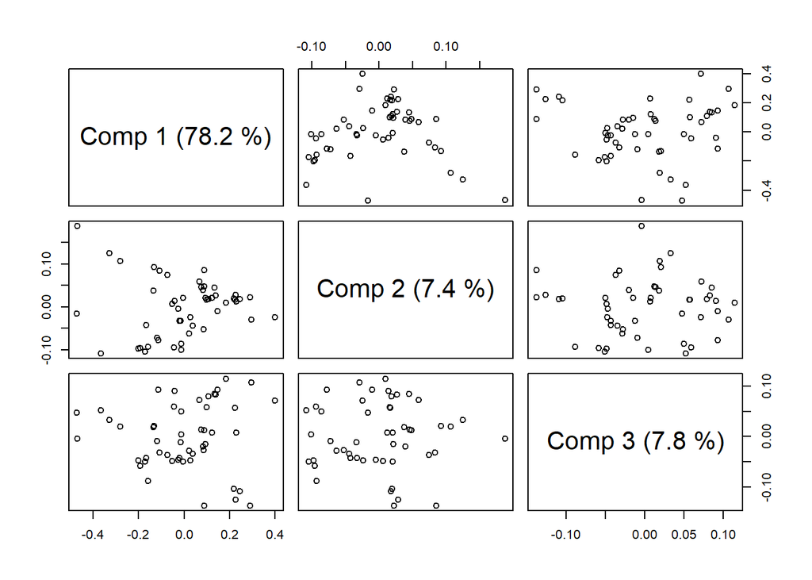

```r
###################################################
plot(gas1, plottype = "scores", comps = 1:3)
```

```r
###################################################
explvar(gas1)
```

```
##     Comp 1     Comp 2     Comp 3     Comp 4     Comp 5     Comp 6     Comp 7
## 78.1707683  7.4122245  7.8241556  2.6577773  0.8768214  0.9466384  0.4921537
##     Comp 8     Comp 9    Comp 10
##  0.4723207  0.1688272  0.1693770
```

Tutaj tak samo jak wcześniej, liczby różnią się zaokrągleniami. W artykule podane są 4 liczby po przecinku gdy tutaj podane jest aż 7.

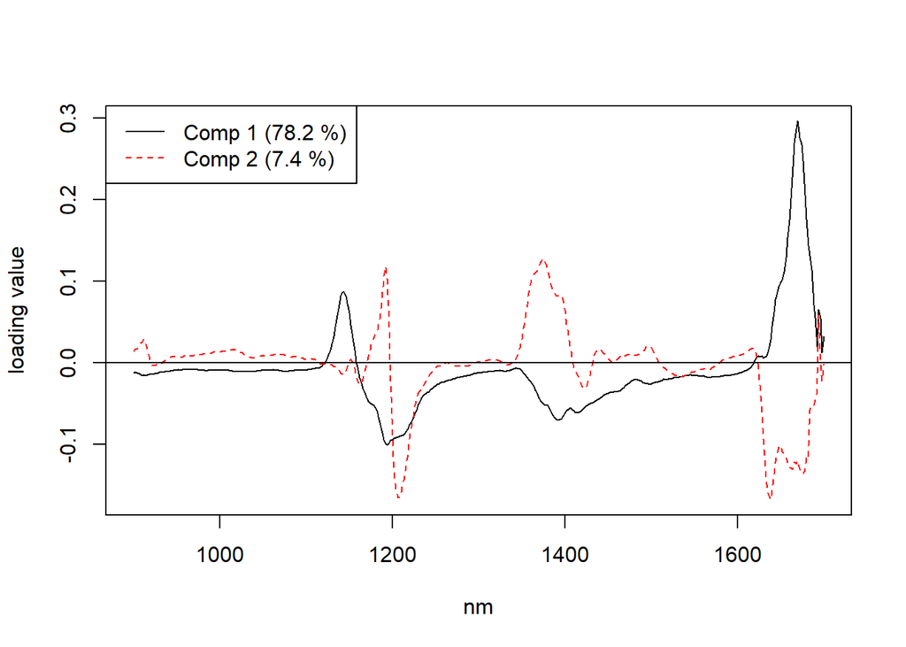

```r
###################################################
plot(gas1, "loadings", comps = 1:2, legendpos = "topleft", labels = "numbers", xlab = "nm")
abline(h = 0)
```

```r
###################################################
predict(gas1, ncomp = 2, newdata = gasTest)
```

```
## , , 2 comps
##
##      octane
## 51 87.94125
## 52 87.25242
## 53 88.15832
## 54 84.96913
## 55 85.15396
## 56 84.51415
## 57 87.56190
## 58 86.84622
## 59 89.18925
## 60 87.09116
```

Podobnie jak wyżej: tutaj 5 miejsc po przecinku, w artykule 2.

```r
###################################################
RMSEP(gas1, newdata = gasTest)
```

```
## (Intercept)      1 comps      2 comps      3 comps      4 comps      5 comps
##      1.5369       1.1696       0.2445       0.2341       0.3287       0.2780
##     6 comps      7 comps      8 comps      9 comps     10 comps
##      0.2703       0.3301       0.3571       0.4090       0.6116
```

```r
###################################################
dens1 <- plsr(density ~ NIR, ncomp = 5, data = yarn)
```

```r
###################################################
dim(oliveoil$sensory)
```

```
## [1] 16  6
```

```r
plsr(sensory ~ chemical, data = oliveoil)
```

```
## Partial least squares regression , fitted with the kernel algorithm.
## Call:
## plsr(formula = sensory ~ chemical, data = oliveoil)
```

```r
###################################################
trainind <- which(yarn$train == TRUE)
dens2 <- update(dens1, subset = trainind)
```

```r
###################################################
dens3 <- update(dens1, ncomp = 10)
```

```r
###################################################
olive1 <- plsr(sensory ~ chemical, scale = TRUE, data = oliveoil)
```

```r
###################################################
gas2 <- plsr(octane ~ msc(NIR), ncomp = 10, data = gasTrain)
```

```r
###################################################
predict(gas2, ncomp = 3, newdata = gasTest)
```

```
## , , 3 comps
##
##      octane
## 51 87.92446
## 52 87.26647
## 53 88.13582
## 54 84.76078
## 55 85.07921
## 56 84.55116
## 57 87.24373
## 58 86.71653
## 59 89.02589
## 60 86.98519
```

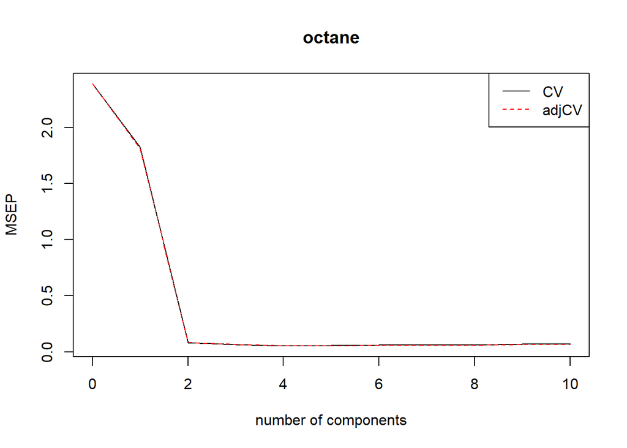

```r
###################################################
gas2.cv <- crossval(gas2, segments = 10)
plot(MSEP(gas2.cv), legendpos='topright')
```

```r
summary(gas2.cv, what = "validation")
```

```
## Data:    X dimension: 50 401
##  Y dimension: 50 1
## Fit method: kernelpls
## Number of components considered: 10
##
## VALIDATION: RMSEP
## Cross-validated using 10 random segments.
##        (Intercept)  1 comps  2 comps  3 comps  4 comps  5 comps  6 comps
## CV           1.545    1.350   0.2833   0.2539   0.2287   0.2329   0.2438
## adjCV        1.545    1.345   0.2817   0.2524   0.2263   0.2297   0.2380
##        7 comps  8 comps  9 comps  10 comps
## CV      0.2424   0.2425   0.2596    0.2624
## adjCV   0.2367   0.2361   0.2515    0.2534
```

Tutaj za to wyniki różnią się o +/- kilka tysięcznych. Znowu jest to winą innego seeda, gdyż tutaj jest kroswalidacja przy uzyciu losowych segmentów.

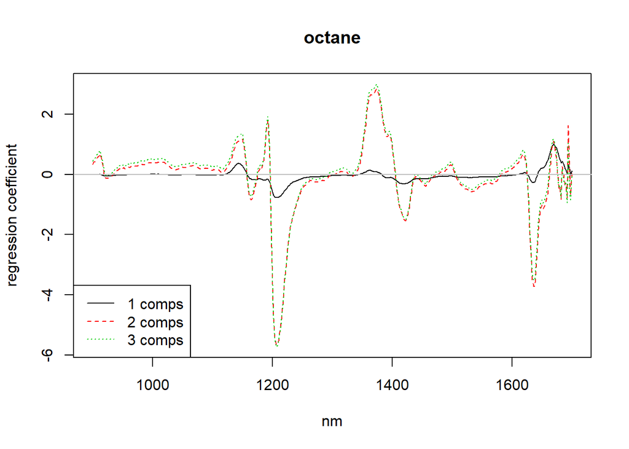

```r
###################################################
plot(gas1, plottype = "coef", ncomp=1:3, legendpos = "bottomleft", labels = "numbers", xlab = "nm")
```

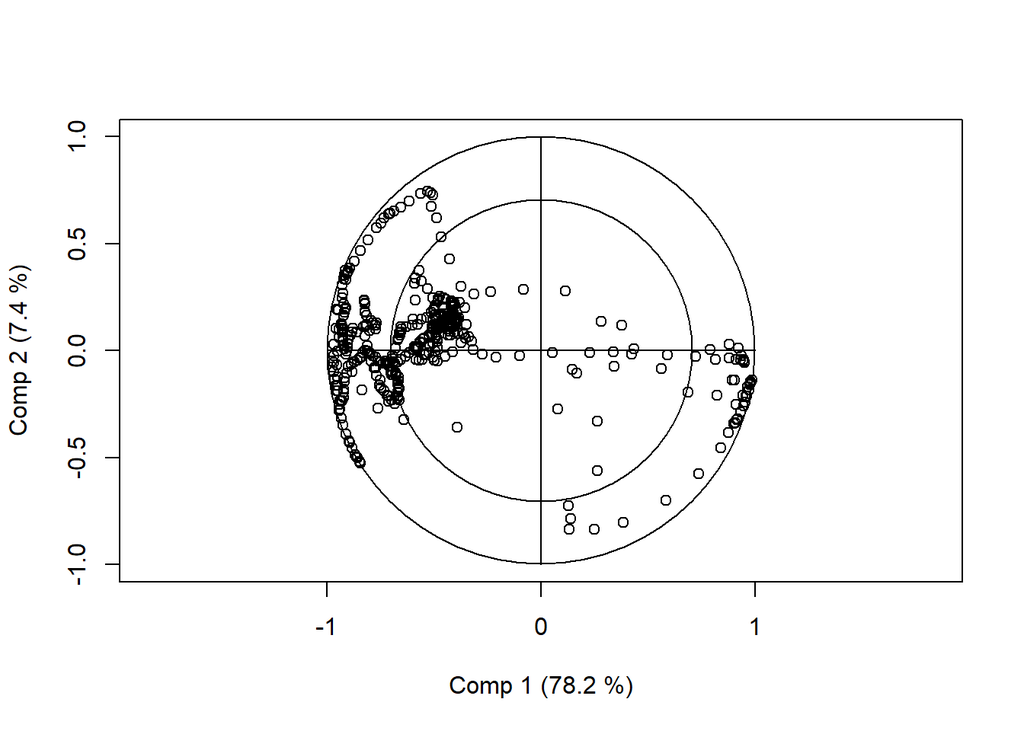

```r
###################################################
plot(gas1, plottype = "correlation")
```

```r
###################################################
predict(gas1, ncomp = 2:3, newdata = gasTest[1:5,])
```

```
## , , 2 comps
##
##      octane
## 51 87.94125
## 52 87.25242
## 53 88.15832
## 54 84.96913
## 55 85.15396
##
## , , 3 comps
##
##      octane
## 51 87.94907
## 52 87.30484
## 53 88.21420
## 54 84.86945
## 55 85.24244
```

Tutaj znowu zaokrąglenia do piątej liczby po przecinku, kiedy w artykule jest do drugiej.

```r
###################################################
predict(gas1, comps = 2, newdata = gasTest[1:5,])
```

```
##      octane
## 51 87.53322
## 52 86.30322
## 53 87.35217
## 54 85.81561
## 55 85.31952
```

Tak samo jak wyżej.

```r
###################################################
drop(predict(gas1, ncomp = 2:3, newdata = gasTest[1:5,]))
```

```
##     2 comps  3 comps
## 51 87.94125 87.94907
## 52 87.25242 87.30484
## 53 88.15832 88.21420
## 54 84.96913 84.86945
## 55 85.15396 85.24244
```

Jak wyżej.

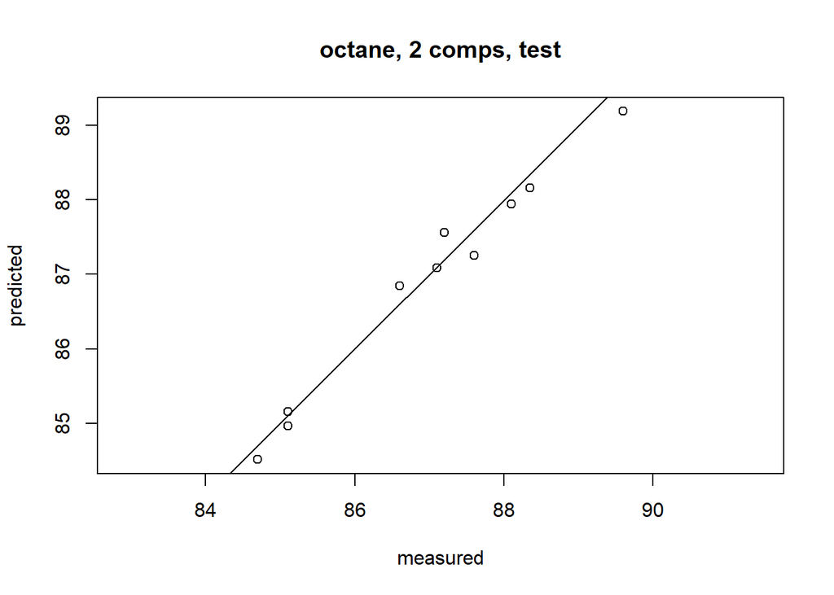

```r
###################################################
predplot(gas1, ncomp = 2, newdata = gasTest, asp = 1, line = TRUE)
```

```r
###################################################
pls.options()
```

```
## $mvralg
## [1] "kernelpls"
##
## $plsralg
## [1] "kernelpls"
##
## $cpplsalg
## [1] "cppls"
##
## $pcralg
## [1] "svdpc"
##
## $parallel
## NULL
##
## $w.tol
## [1] 2.220446e-16
##
## $X.tol
## [1] 1e-12
```

```r
###################################################
pls.options(plsralg = "oscorespls")
```

```r
###################################################
pls.options("plsralg")
```

```
## $plsralg
## [1] "oscorespls"
```

```r
rm(.pls.Options)
pls.options("plsralg")
```

```
## $plsralg
## [1] "oscorespls"
```

Tutaj tak samo `$plsralg` powinno mieć wartość `"kernelpls"`.

```r
###################################################
X <- gasTrain$NIR
Y <- gasTrain$octane
ncomp <- 5
cvPreds <- matrix(nrow = nrow(X), ncol = ncomp)
for (i in 1:nrow(X)) {
    fit <- simpls.fit(X[-i,], Y[-i], ncomp = ncomp, stripped = TRUE)
    cvPreds[i,] <- (X[i,] - fit$Xmeans) %*% drop(fit$coefficients) + fit$Ymeans
}
```

```r
###################################################
sqrt(colMeans((cvPreds - Y)^2))
```

```
## [1] 1.3569509 0.2966201 0.2524084 0.2475784 0.2397937
```

Tak samo jak wcześniej tutaj zaokrąglenia do siódmej liczby a nie jak w artykule do czwartej.

### 0.1.1 Podsumowanie

Artykuł jest bardzo reprodukowalny. Wyniki są praktycznie takie same, różnią się jedynie w przypadku bardziej dokładnych rozwinięć i losowo wybranych obiektów, prawdopodobnie przez innego seeda. Widać też że pakiet ten został od zamieszczenia go rozwinięty.